# Lab05: Logistic & Poisson Regression

Yalin Yang

2021-05-03

```r
# load helper package
library(car)
data(Mroz)
attach(Mroz)
```

# Task 2 Model discussion [2 points]

## Qa

[a] Build a logistic regression model for the probability of lfp with these independent variables and give the 95% confidence intervals around the estimated logistic regression parameters

```r
GLM.01 <- glm(lfp ~ k5 + k618 + age + wc + hc + lwg + inc, family=binomial(logit), trace=TRUE, data=Mroz)
```

```
Deviance = 905.4065 Iterations - 1
Deviance = 905.2659 Iterations - 2
Deviance = 905.2659 Iterations - 3
Deviance = 905.2659 Iterations - 4
```

```r
summary(GLM.01)  #slope is for logit, not for probability
```

```
Call:
glm(formula = lfp ~ k5 + k618 + age + wc + hc + lwg + inc, family = binomial(logit),
    data = Mroz, trace = TRUE)

Deviance Residuals:
    Min       1Q   Median       3Q      Max
-2.1062  -1.0900   0.5978   0.9709   2.1893

Coefficients:
             Estimate Std. Error z value Pr(>|z|)
(Intercept)  3.182140   0.644375   4.938 7.88e-07 ***
k5          -1.462913   0.197001  -7.426 1.12e-13 ***
k618        -0.064571   0.068001  -0.950 0.342337
age         -0.062871   0.012783  -4.918 8.73e-07 ***
wcyes        0.807274   0.229980   3.510 0.000448 ***
hcyes        0.111734   0.206040   0.542 0.587618
lwg          0.604693   0.150818   4.009 6.09e-05 ***
inc         -0.034446   0.008208  -4.196 2.71e-05 ***
---
Signif. codes:  0 ‘***’ 0.001 ‘**’ 0.01 ‘*’ 0.05 ‘.’ 0.1 ‘ ’ 1

(Dispersion parameter for binomial family taken to be 1)

    Null deviance: 1029.75  on 752  degrees of freedom
Residual deviance:  905.27  on 745  degrees of freedom
AIC: 921.27

Number of Fisher Scoring iterations: 4
```

```r
vif(GLM.01)
```

```
      k5     k618      age       wc       hc      lwg
1.388895 1.258626 1.648608 1.497246 1.547911 1.093559
     inc
1.242135
```

```r
# confint(GLM.01, level=0.95, type="Wald",trace = FALSE)
```

[output not shown]

## Qb

Discuss your model output in the light of your stated hypotheses from task 1.

Almost all variables fit the previous assumption with a significant impact on the dependent variable except ‘k618’ and ‘hc’. For ‘k618’, I guess since children within 6 to 18 would stay at schools most of the time, it is not a big problem for moms to take care of them after work. For “husband education”, it surprised me it does not have a significant influence on the dependent variable. However, family income still has a significant impact but a low slope, which means women are more independent than I assumed.

## Qc

Interpret the calibrated logistic regression model in terms of **probabilities** by using an **all effects plot** (i.e., the “other” variables are at their average level).

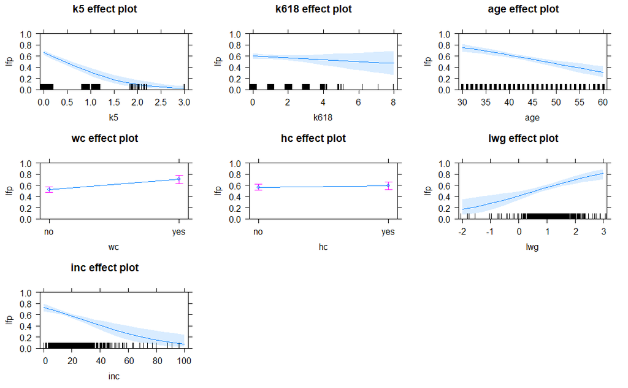

```r
library(effects)     # Important: Use version 3.0-6 or newer
plot(allEffects(GLM.01), type="response", ylim=c(0,1), ask=FALSE)
```

K5: A higher value leads to a lower probability. For most families have 0 or 1 child with the age from 0 to 5, they have 60% and 30% probability to take work, respectively. If this value larger than 1, wives are very unlikely to take works. K618: The regression line is almost flat, which means not many influences from it. The average around 58% means there are 58% of our observed records have a work. Age: Higher age lower probability to work. The average age of 45 years old corresponds to a 50% probability to work. Wife Education: A higher education level corresponds to a higher probability to work. Husband education: flat, not many impacts. Family income: A Higher family income would lower the probability to work. Expected wage rate：A Higher expected wage rate would increase the probability to work, and this slope is sharpest since the wage is the first considering when decided to work or not.

# Task 3 : Perform a likelihood ratio test [1 point]

Refine the model from task 2 by dropping all variables which you deem to be not relevant. Test whether these variables jointly have explanatory power or not. Properly state in statistical terminology the null and the alternative hypotheses.

```r
GLM.02 <- glm(lfp ~ k5 + age + wc + lwg + inc, family=binomial(logit), trace=TRUE, data=Mroz)
```

```
Deviance = 906.5433 Iterations - 1
Deviance = 906.4554 Iterations - 2
Deviance = 906.4554 Iterations - 3
```

```r
summary(GLM.02)  #slope is for logit, not for probability
```

```
Call:
glm(formula = lfp ~ k5 + age + wc + lwg + inc, family = binomial(logit),
    data = Mroz, trace = TRUE)

Deviance Residuals:
    Min       1Q   Median       3Q      Max
-2.0428  -1.0853   0.6015   0.9697   2.1801

Coefficients:
            Estimate Std. Error z value Pr(>|z|)
(Intercept)  2.90193    0.54290   5.345 9.03e-08 ***
k5          -1.43180    0.19320  -7.411 1.25e-13 ***
age         -0.05853    0.01142  -5.127 2.94e-07 ***
wcyes        0.87237    0.20639   4.227 2.37e-05 ***
lwg          0.61568    0.15014   4.101 4.12e-05 ***
inc         -0.03367    0.00780  -4.317 1.58e-05 ***
---
Signif. codes:  0 ‘***’ 0.001 ‘**’ 0.01 ‘*’ 0.05 ‘.’ 0.1 ‘ ’ 1

(Dispersion parameter for binomial family taken to be 1)

    Null deviance: 1029.75  on 752  degrees of freedom
Residual deviance:  906.46  on 747  degrees of freedom
AIC: 918.46

Number of Fisher Scoring iterations: 3
```

```r
## Likelihood Ratio Test
anova(GLM.02,GLM.01,test = 'LRT')
```

```
Analysis of Deviance Table

Model 1: lfp ~ k5 + age + wc + lwg + inc
Model 2: lfp ~ k5 + k618 + age + wc + hc + lwg + inc
  Resid. Df Resid. Dev Df Deviance Pr(>Chi)
1       747     906.46
2       745     905.27  2   1.1895   0.5517
```

# Task 4: Conditional effects plots [2 points]

Discuss your plots for the two scenarios: How does the labor force participation probability vary for women in both groups? (conditional effects plot)

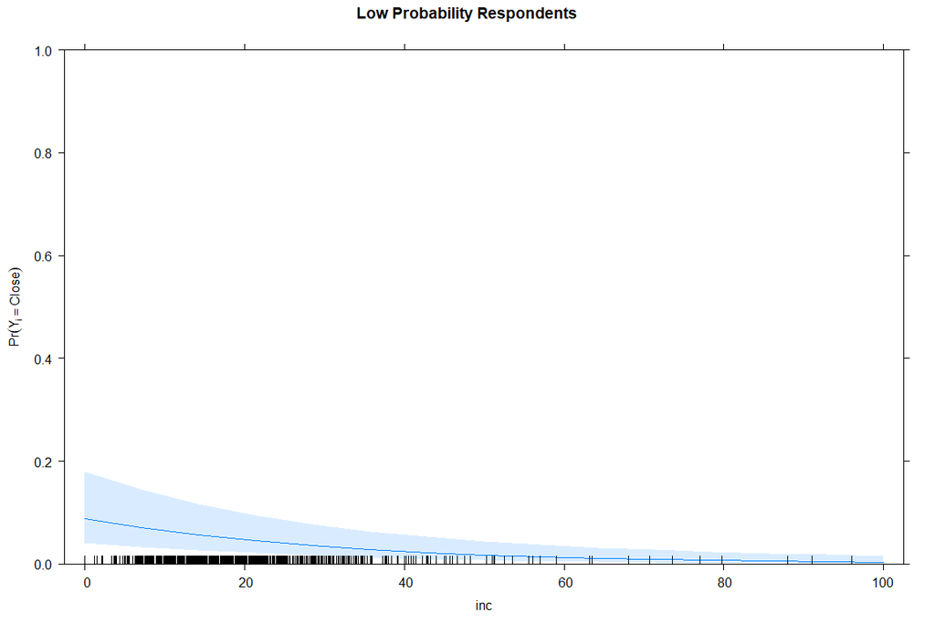

```r
# Low prob respondent
eff.GLM.low <- effect("inc",GLM.02,
                      given.values = c(k5 = 2,age = 49,"wcyes" = 0,lwg = 0.81))
plot(eff.GLM.low, type="response", ylim=c(0,1), ylab=expression(Pr(Y[i]=="Close")),
     main="Low Probability Respondents")
```

Low Probability Case: If there is a 49 years old woman with 2 children under 5, and she does not have a college degree, it is very unlikely for her to work. As shown in graphs, unless the family income is pretty low, which means she may have to work for a living, the probability of working is near to 0.

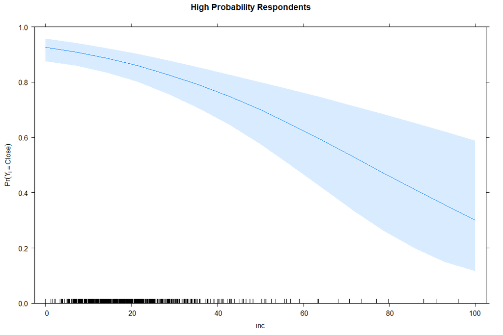

```r
# High prob respondent
eff.GLM.hi <- effect("inc",GLM.02,
                     given.values=c(k5 = 0,age = 36,"wcyes" = 1,lwg = 1.40))
plot(eff.GLM.hi, type="response", ylim=c(0,1), ylab=expression(Pr(Y[i]=="Close")),
     main="High Probability Respondents")
```

**Part 2: Poisson and Logistic Regression [4 points]**

Use the data-frame cancer in the library CancerSEA. You can install the library with the command install.packages(“Drive:\Path\CancerSEA_0.9.6.tar.gz”, repos=NULL). Show your results and briefly discuss them.

# Task 5

Run a Poisson regression model on the annual raw counts of white male lung cancer deaths for the period 1970 to 1994. Make sure to use a proper offset in the link-function specification to account for the expected number of death based on the population size and age distribution in each State Economic Area. [1 points]

Select as independent variables $~URBRUR+RAD_MD+I(RAD_MD^2)+TOBACCO$.

```r
install.packages("CancerSEA_0.9.6.tar.gz", repos=NULL)
```

[output not shown]

```r
lm.poisson <- glm(L_WM_P2_CN~URBRUR+RAD_MD+I(RAD_MD^2)+TOBACCO, offset=log(L_WM_P2_EX),family=poisson, data=cancer)
summary(lm.poisson)
```

```
Call:
glm(formula = L_WM_P2_CN ~ URBRUR + RAD_MD + I(RAD_MD^2) + TOBACCO,
    family = poisson, data = cancer, offset = log(L_WM_P2_EX))

Deviance Residuals:
     Min        1Q    Median        3Q       Max
-23.3141   -3.7661   -0.9355    2.1832   26.2712

Coefficients:
              Estimate Std. Error z value Pr(>|z|)
(Intercept) -0.2038740  0.0087113  -23.40   <2e-16 ***
URBRURurban  0.2904292  0.0028756  101.00   <2e-16 ***
RAD_MD      -0.2329147  0.0064603  -36.05   <2e-16 ***
I(RAD_MD^2)  0.0340182  0.0019232   17.69   <2e-16 ***
TOBACCO      0.0093650  0.0003904   23.99   <2e-16 ***
---
Signif. codes:  0 ‘***’ 0.001 ‘**’ 0.01 ‘*’ 0.05 ‘.’ 0.1 ‘ ’ 1

(Dispersion parameter for poisson family taken to be 1)

    Null deviance: 28494  on 507  degrees of freedom
Residual deviance: 12765  on 503  degrees of freedom
AIC: 16978

Number of Fisher Scoring iterations: 4
```

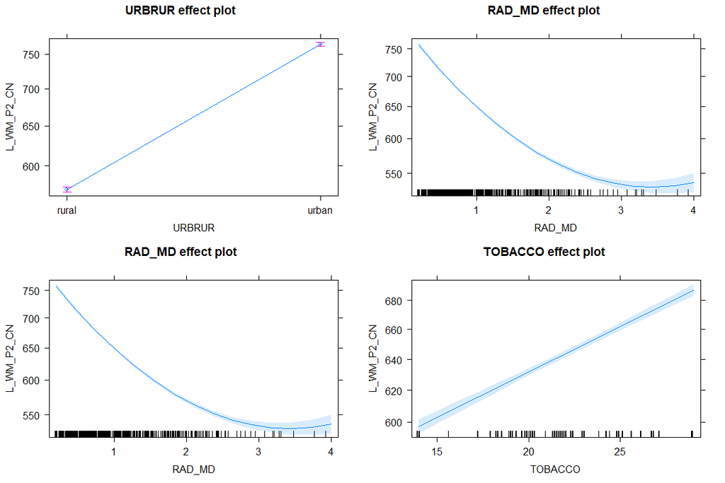

```r
plot(allEffects(lm.poisson))
```

The expected number of cases, given the observed age-distribution, is given by the variable L_WM_P2_EX. It will become the offset. The log-transformation needs to be applied on this offset to match the link function of the Poisson model.

# Task 6

Run a logistic regression model for the directly age-standardized white male lung cancer death rates per 100.000 persons at risk. Caution: you need to re-scale the rates, so they become probabilities. Since we are dealing with a binomial distribution rather than a binary distribution you need to specify a (half of the population) proper weight variable to account for the population at risk, i.e., half of the population in 1980. [1 points] Select as independent variables $~URBRUR+RAD_MD+I(RAD_MD^2)+TOBACCO$.

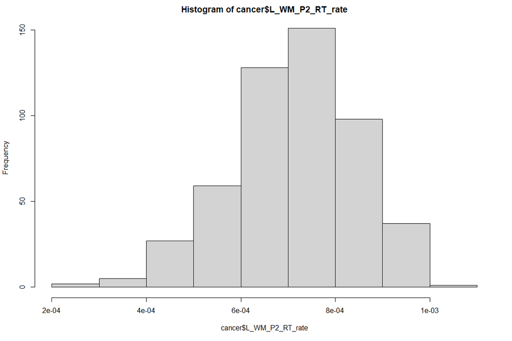

```r
cancer$L_WM_P2_RT_rate <- cancer$L_WM_P2_RT/100000
hist(cancer$L_WM_P2_RT_rate)
```

```r
GLM.01 <- glm(L_WM_P2_RT_rate~ URBRUR+RAD_MD+I(RAD_MD^2)+TOBACCO, family=binomial(logit), weights = (POP1980/2),trace=TRUE, data=cancer)
```

```
Deviance = 1507.898 Iterations - 1
Deviance = 1501.131 Iterations - 2
Deviance = 1501.131 Iterations - 3
Deviance = 1501.131 Iterations - 4
```

```r
summary(GLM.01)  #slope is for logit, not for probability
```

```
Call:
glm(formula = L_WM_P2_RT_rate ~ URBRUR + RAD_MD + I(RAD_MD^2) +
    TOBACCO, family = binomial(logit), data = cancer, weights = (POP1980/2),
    trace = TRUE)

Deviance Residuals:
    Min       1Q   Median       3Q      Max
-8.6291  -0.7955   0.1027   1.0905   6.0479

Coefficients:
              Estimate Std. Error  z value Pr(>|z|)
(Intercept) -7.6223693  0.0216306 -352.388   <2e-16 ***
URBRURurban  0.0069212  0.0071018    0.975     0.33
RAD_MD      -0.2279194  0.0158996  -14.335   <2e-16 ***
I(RAD_MD^2)  0.0434584  0.0049315    8.812   <2e-16 ***
TOBACCO      0.0239206  0.0009424   25.382   <2e-16 ***
---
Signif. codes:  0 ‘***’ 0.001 ‘**’ 0.01 ‘*’ 0.05 ‘.’ 0.1 ‘ ’ 1

(Dispersion parameter for binomial family taken to be 1)

    Null deviance: 2345.2  on 507  degrees of freedom
Residual deviance: 1501.1  on 503  degrees of freedom
AIC: 4816.9

Number of Fisher Scoring iterations: 4
```

# Task 7

For the logistic regression model from task 6 generate a conditional effects plot with respect to RAD_MD (all other variable at their average levels). Make sure to have probabilities on y-axis and not logits. [1 point]

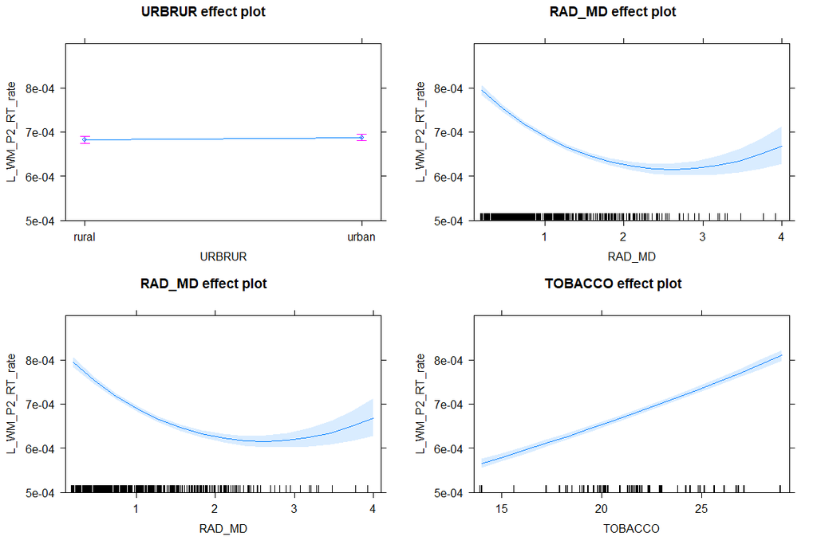

```r
plot(allEffects(GLM.01), type="response", ylim=c(0.0005,0.0009))
```

Compared to the Poisson model evaluating lung cancer the logistic model is not as significant (see standard errors and width of the confidence intervals) anymore. The urban-rural effect is even insignificant now. The deviance dropped only by 35%.

# Task 8

Rerun the model from task 6 allowing explicitly modeling potential over-dispersion. Compare both models and interpret the estimated over-dispersion parameter. [1 point]

```r
GLM.02 <- glm(L_WM_P2_RT_rate~ URBRUR+RAD_MD+I(RAD_MD^2)+TOBACCO, family=quasibinomial, weights = (POP1980/2),trace=TRUE, data=cancer)
```

```
Deviance = 1507.898 Iterations - 1
Deviance = 1501.131 Iterations - 2
Deviance = 1501.131 Iterations - 3
Deviance = 1501.131 Iterations - 4
```

```r
summary(GLM.02)  #slope is for logit, not for probability
```

```
Call:
glm(formula = L_WM_P2_RT_rate ~ URBRUR + RAD_MD + I(RAD_MD^2) +
    TOBACCO, family = quasibinomial, data = cancer, weights = (POP1980/2),
    trace = TRUE)

Deviance Residuals:
    Min       1Q   Median       3Q      Max
-8.6291  -0.7955   0.1027   1.0905   6.0479

Coefficients:
             Estimate Std. Error  t value Pr(>|t|)
(Intercept) -7.622369   0.037132 -205.276  < 2e-16 ***
URBRURurban  0.006921   0.012191    0.568     0.57
RAD_MD      -0.227919   0.027294   -8.351 6.64e-16 ***
I(RAD_MD^2)  0.043458   0.008466    5.134 4.07e-07 ***
TOBACCO      0.023921   0.001618   14.786  < 2e-16 ***
---
Signif. codes:  0 ‘***’ 0.001 ‘**’ 0.01 ‘*’ 0.05 ‘.’ 0.1 ‘ ’ 1

(Dispersion parameter for quasibinomial family taken to be 2.946905)

    Null deviance: 2345.2  on 507  degrees of freedom
Residual deviance: 1501.1  on 503  degrees of freedom
AIC: NA

Number of Fisher Scoring iterations: 4
```

**Part 3 Modeling Interregional Migration with Poisson Regression [2 points]**

# Task 9

Estimate the basic gravity model $E(m_{ij}) = \beta_0 * p_i^{\beta_1} * p_j^{\beta_2} * d_{ij}^{\beta_3}$ with Poisson regression and transforming the right-hand-side of the equation into a linear equation in the unknown regression coefficients $\beta_0,\beta_1,\beta_2,\beta_3$ by applying the logarithm. [1 point]

```r
upfing <- foreign::read.spss("UPFING.SAV", use.value.labels=TRUE, to.data.frame=TRUE)
```

```r
mod01 <- glm(MIJ~log(PI)+log(PJ)+log(DIJ), data=upfing, family=poisson,subset=(I!=J))
summary(mod01)
```

```
Call:
glm(formula = MIJ ~ log(PI) + log(PJ) + log(DIJ), family = poisson,
    data = upfing, subset = (I != J))

Deviance Residuals:
    Min       1Q   Median       3Q      Max
-253.43   -60.75   -32.42     5.52   408.13

Coefficients:
              Estimate Std. Error z value Pr(>|z|)
(Intercept) -7.0409657  0.0241716  -291.3   <2e-16 ***
log(PI)      0.7142001  0.0009334   765.2   <2e-16 ***
log(PJ)      0.5838710  0.0009029   646.7   <2e-16 ***
log(DIJ)    -0.3154750  0.0011822  -266.9   <2e-16 ***
---
Signif. codes:  0 ‘***’ 0.001 ‘**’ 0.01 ‘*’ 0.05 ‘.’ 0.1 ‘ ’ 1

(Dispersion parameter for poisson family taken to be 1)

    Null deviance: 2097541  on 89  degrees of freedom
Residual deviance:  891051  on 86  degrees of freedom
AIC: 891967

Number of Fisher Scoring iterations: 5
```

# Task 10

Interpret the estimate regression coefficients in terms of their estimated signs. How do the origin and destination populations as well as the interprovincial distances influence the migration flows? [1 point]

The regression coefficients of origin and destination populations are positive whereas the regression coefficient of distance is negative. Consequently, with increasing population sizes the migration flow between an origin-destination pair increases. Because the magnitude of the regression coefficient associated log(PI) is larger than that log(PJ), large origin populations more emissive compare to the attractions based on large destination population sizes. The inter-regional distance becomes a deterrence of migration. The further distance between two regions, the less migration flows are expected.

```r
plot(allEffects(mod01))
```

[output not shown]